# Alzheimers Disease Analysis

Bijo Varghese, Hong Fu and Jessica Kentwell

# The Problem

## Background

- 1 in 3 older adult dies with Alzheimer’s*
- Exact cause is not fully understood
- Early detection is critical

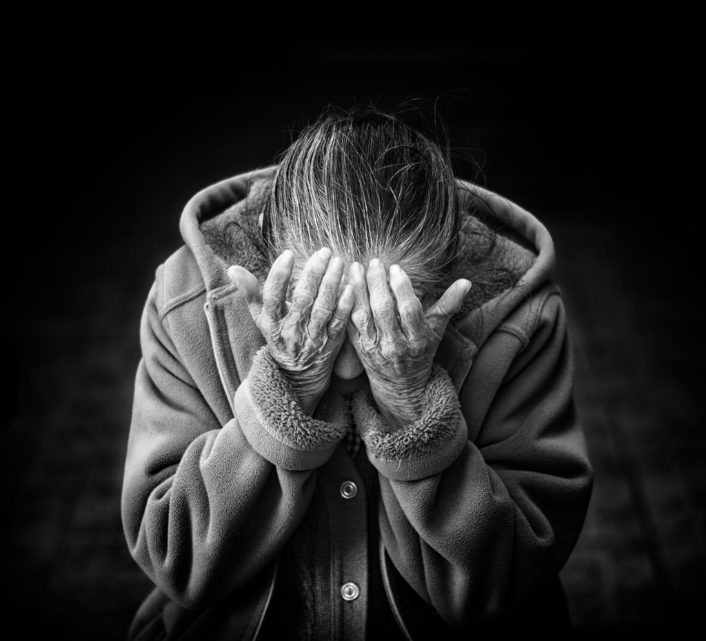

*According to Alzheimer’s Association in 2024

## Goal

To create a **right sized** model with **adequate performance** that correctly predicts if the patient has **Alzheimer’s** or **not**.

## Dataset Description

- Patient Information
  - Demographic Details
  - Lifestyle Factors
- Medical History
- Clinical Measurements
- Cognitive and Functional Assessments
- Symptoms
- Diagnosis Information (Alzheimer’s or No Alzheimers)

2139 Observations  
33 Features

| Variables | Description | Data Type |
| --- | --- | --- |
| Age | Age of the patient, ranges from 60 to 90 years. | interval |
| Gender | Gender of the patients, 0: Male, 1: Female | nominal |
| Ethnicity | Ethnicity of the patients, 0: Caucasian, 1: African American, 2: Asian, 3: Other | nominal |
| EducationLevel | Education level of the patients, 0: None, 1: High School, 2: Bachelor's, 3: Higher | ordinal |
| BMI | BMI, ranging from 15 to 40 | ratio |
| Smoking | Smoking status, 0: No, 1: Yes | nominal |
| AlcoholConsumption | Weekly alcohol consumption in units, ranging from 0 to 20 | ratio |
| PhysicalActivity | Weekly physical activity in hours, ranging from 0 to 10 | ratio |
| DietQuality | Diet quality score, ranging from 0 to 10 | ratio |
| SleepQuality | Sleep quality score, ranging from 4 to 10 | ratio |
| FamilyHistoryAlzheimers | Family history of Alzheimer's Disease, 0: No, 1: Yes | nominal |
| CardiovascularDisease | Presence of cardiovascular disease, 0: No, 1: Yes | nominal |
| Diabetes | Presence of diabetes, 0: No, 1: Yes | nominal |
| Depression | Presence of depression, 0: No, 1: Yes | nominal |
| HeadInjury | History of head injury, 0: No, 1: Yes | nominal |
| Hypertension | Presence of hypertension, 0: No, 1: Yes | nominal |
| SystolicBP | Systolic blood pressure, ranging from 90 to 180 mmHg | interval |
| DiastolicBP | Diastolic blood pressure, ranging from 60 to 120 mmHg | interval |
| CholesterolTotal | Total cholesterol levels, ranging from 150 to 300 mg/dL | interval |
| CholesterolLDL | Low-density lipoprotein cholesterol levels, ranging from 50 to 200 mg/dL. | interval |
| CholesterolHDL | High-density lipoprotein cholesterol levels, ranging from 20 to 100 mg/dL. | interval |
| CholesterolTriglyerides | Triglycerides levels, ranging from 50 to 400 mg/dL | interval |
| MMSE | Mini-Mental State Examination score, ranging from 0 to 30. Lower scores indicate cognitive impairment. | ordinal |
| FunctionalAssessment | Functional assessment score, ranging from 0 to 10. Lower scores indicate greater impairment. | ordinal |
| MemoryComplaints | Presence of memory complaints, 0: No, 1: Yes | nominal |
| BehavioralProblems | Presence of behavioral problems, 0: No, 1: Yes | nominal |
| ADL | Activities of Daily Living score, ranging from 0 to 10. Lower scores indicate greater impairment. | ordinal |
| Confusion | Presence of confusion, 0: No, 1: Yes | nominal |
| Disorientation | Presence of disorientation, 0: No, 1: Yes | nominal |
| PersonalityChanges | Presence of personality changes, 0: No, 1: Yes | nominal |
| DifficultyCompletingTasks | Presence of difficulty completing tasks, 0: No, 1: Yes | nominal |
| Forgetfulness | Presence of forgetfulness, 0: No, 1: Yes | nominal |
| Diagnosis | Diagnosis status for Alzheimer's Disease, 0: No, 1: Yes | nominal |